# Atividade Prática 4 — Respostas

Econometria Aplicada à Finanças  
Mestrado Profissional em Administração

Autor

Jonathan Vargas Silva

Data de Publicação

31 de agosto de 2026

## Preparação dos dados

Crie a variável `high_income` conforme solicitado no enunciado.

```r
# Cria o indicador de alta renda
life_df <- life_df |>
  dplyr::mutate(
    high_income = dplyr::if_else(income_quartile == 4, 1, 0)
  )
```

## Questão 1: Testando a presença de heterocedasticidade

**a.** Estime o modelo do item **l** da Atividade Prática 2, construa o gráfico dos resíduos contra `pct_smoke` e interprete o diagnóstico visual.

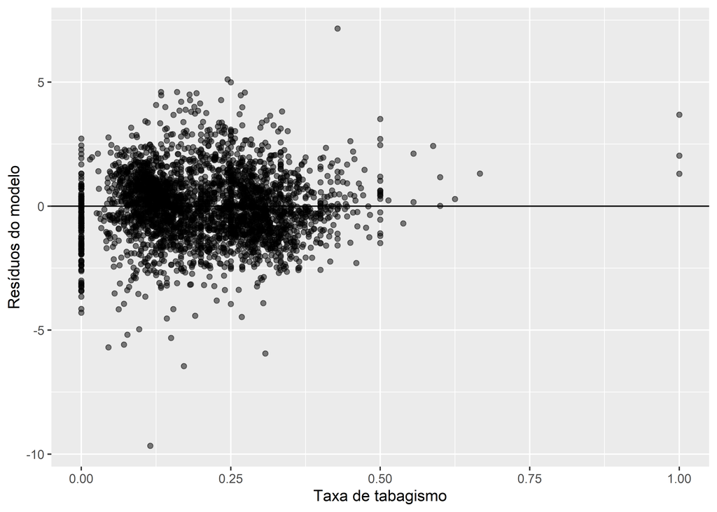

Resíduos do modelo contra a taxa de tabagismo.

```r
# Estima o modelo do item l da Atividade Prática 2
modelo_l <- stats::lm(
  life_exp ~ pct_smoke + high_income + is_urban,
  data = life_df
)

# Obtenha os resíduos e acrescente-os aos dados
life_df <- life_df |>
  mutate(residuos_l = stats::residuals(modelo_l))

# Construa o gráfico dos resíduos contra pct_smoke
ggplot2::ggplot(life_df, aes(x = pct_smoke, y = residuos_l)) +
  ggplot2::geom_point(alpha = 0.5) +
  ggplot2::geom_hline(yintercept = 0) +
  ggplot2::labs(x = "Taxa de tabagismo", y = "Resíduos do modelo")
```

**b.** Mantida a exogeneidade, explique as consequências da heterocedasticidade para os estimadores dos coeficientes, os erros-padrão usuais e a eficiência do MQO.

Mantida a exogeneidade, a heterocedasticidade mantém os estimadores dos coeficientes, em média, corretos. Entretanto, os erros-padrão usuais ficam incorretos, prejudicando testes de hipótese e intervalos de confiança. Por consequência, o MQO deixa de ser eficiente.

**c.** Realize o teste de Goldfeld–Quandt. Apresente e interprete as hipóteses, a estatística, o valor-*p* e a decisão.

```r
# Execute o teste de Goldfeld–Quandt ordenado pela taxa de tabagismo
resultado_gq <- lmtest::gqtest(
  life_exp ~ pct_smoke + high_income + is_urban,
  data = life_df,
  order.by = ~ pct_smoke,
  point = 0.5,
  fraction = 1/3,
  alternative = "two.sided"
)

# Exibe o resultado do teste
resultado_gq
```

```
    Goldfeld-Quandt test

data:  life_exp ~ pct_smoke + high_income + is_urban
GQ = 0.866, df1 = 1032, df2 = 1031, p-value = 0.021
alternative hypothesis: variance changes from segment 1 to 2
```

**d.** Realize o teste de White. Apresente e interprete as hipóteses, a estatística, o valor-*p* e a decisão.

```r
# Execute o teste de White a partir do modelo estimado
resultado_white <- whitestrap::white_test(modelo_l)

# Exiba o resultado do teste
resultado_white
```

```
White's test results

Null hypothesis: Homoskedasticity of the residuals
Alternative hypothesis: Heteroskedasticity of the residuals
Test Statistic: 39.96
P-value: 0
```

**e.** Os testes de Goldfeld–Quandt e de White precisam sempre concordar? Compare os resultados desta aplicação e explique.

## Questão 2: Convivendo com a heterocedasticidade

**a.** Estime o modelo com interação entre tabagismo e alta renda, apresente os resultados, identifique os grupos comparados e interprete o termo de interação.

```r
# Estima o modelo com interação entre tabagismo e alta renda
modelo_interacao <- stats::lm(
  life_exp ~ pct_smoke * high_income + is_urban,
  data = life_df
)

# Apresenta os resultados da estimação
modelo_interacao
```

```
Call:
stats::lm(formula = life_exp ~ pct_smoke * high_income + is_urban,
    data = life_df)

Coefficients:
          (Intercept)              pct_smoke            high_income
              80.5437                -6.0686                 5.8151
             is_urban  pct_smoke:high_income
               0.0326                 2.9078
```

O termo de interação mede a diferença na inclinação entre os dois grupos de renda: o quanto o efeito do tabagismo sobre a expectativa de vida muda quando comparamos o grupo de renda alta com o grupo de renda baixa. Se esse coeficiente for positivo, o efeito negativo do tabagismo é menor no grupo de renda alta.

**b.** Substitua `high_income = 0` e `high_income = 1` na equação estimada, identifique a inclinação da relação entre tabagismo e expectativa de vida em cada grupo e interprete um aumento de dez pontos percentuais no tabagismo.

```r
# Define a função
coefs <- coef(modelo_interacao)

# Calcula a inclinação do grupo de renda mais baixa
inclinacao_baixa_renda <- coefs["pct_smoke"]

# Calcula a inclinação do grupo de renda mais alta
inclinacao_alta_renda  <- coefs["pct_smoke"] + coefs["pct_smoke:high_income"]

# Calcula as variações associadas a dez pontos percentuais
variacao_baixa_renda <- inclinacao_baixa_renda * 0.10
variacao_alta_renda  <- inclinacao_alta_renda * 0.10

# Exibe os resultados
inclinacao_baixa_renda
```

```
pct_smoke
  -6.0686
```

```r
inclinacao_alta_renda
```

```
pct_smoke
  -3.1608
```

```r
variacao_baixa_renda
```

```
pct_smoke
 -0.60686
```

```r
variacao_alta_renda
```

```
pct_smoke
 -0.31608
```

**c.** Calcule erros-padrão HC3 e compare a inferência sobre o termo de interação com a inferência usual.

```r
# Estima a matriz de covariância com a correção HC3
vcov_hc3 <- sandwich::vcovHC(modelo_interacao, type = "HC3")

# Calcula a inferência com a matriz HC3
resultado_hc3 <- lmtest::coeftest(modelo_interacao, vcov. = vcov_hc3)

# Compara a inferência usual e HC3 para o termo de interação
summary(modelo_interacao)$coefficients
```

[output not shown]

```r
resultado_hc3
```

```
t test of coefficients:

                      Estimate Std. Error t value             Pr(>|t|)
(Intercept)            80.5437     0.1697  474.75 < 0.0000000000000002 ***
pct_smoke              -6.0686     0.5185  -11.70 < 0.0000000000000002 ***
high_income             5.8151     0.1764   32.97 < 0.0000000000000002 ***
is_urban                0.0326     0.0681    0.48              0.63259
pct_smoke:high_income   2.9078     0.7608    3.82              0.00014 ***
---
Signif. codes:  0 '***' 0.001 '**' 0.01 '*' 0.05 '.' 0.1 ' ' 1
```

**d.** Estime o modelo por MQP com `weights = pop`, calcule HC3 para os dois modelos e compare os resultados. Discuta também o significado da ponderação.

```r
# Estima o modelo ponderado pela população do condado
modelo_mqp <- stats::lm(
  life_exp ~ pct_smoke * high_income + is_urban,
  data = life_df,
  weights = pop
)

# Calcule a matriz HC3 e a inferência do modelo ponderado
vcov_mqp_hc3 <- sandwich::vcovHC(modelo_mqp, type = "HC3")

# Compare os modelos não ponderado e ponderado com HC3


# Reúna os modelos não ponderado e ponderado em uma lista nomeada
modelos <- list(
  "MQO (não ponderado)" = modelo_interacao,
  "MQP (ponderado por pop)" = modelo_mqp
)

# Reúna as respectivas matrizes HC3 em outra lista, na mesma ordem
matrizes_vcov <- list(
  vcov_hc3,
  vcov_mqp_hc3
)

# Apresente os dois modelos lado a lado com modelsummary
modelsummary::modelsummary(
  models = modelos,
  vcov = matrizes_vcov,
  statistic = "({std.error})",
  stars = TRUE,
  fmt = 3
)
```

|  | MQO (não ponderado) | MQP (ponderado por pop) |
| --- | --- | --- |
| (Intercept) | 80.544*** | 84.786*** |
|  | (0.170) | (0.649) |
| pct_smoke | -6.069*** | -20.699*** |
|  | (0.519) | (2.180) |
| high_income | 5.815*** | 2.142** |
|  | (0.176) | (0.667) |
| is_urban | 0.033 | 0.278*** |
|  | (0.068) | (0.083) |
| pct_smoke × high_income | 2.908*** | 13.400*** |
|  | (0.761) | (2.295) |
| Num.Obs. | 3106 | 3106 |
| R2 | 0.874 | 0.887 |
| R2 Adj. | 0.874 | 0.886 |
| AIC | 10717.8 | 12343.8 |
| BIC | 10754.1 | 12380.0 |
| Log.Lik. | -5352.924 | -6165.892 |
| RMSE | 1.36 | 1.63 |
| Std.Errors | Custom | Custom |

+ p < 0.1, * p < 0.05, ** p < 0.01, *** p < 0.001

## Questão 3: Erros-padrão robustos a agrupamentos

**a.** Explique por que os erros das duas observações pertencentes ao mesmo condado podem estar correlacionados.

**b.** Estime o modelo com erros-padrão robustos a agrupamentos e agrupamento por condado. Apresente os resultados.

```r
# Estima o modelo com erros-padrão robustos a agrupamentos por condado
modelo_condado <- fixest::feols(
  life_exp ~ pct_smoke * high_income + is_urban,
  data = life_df,
  vcov = ~ county_code
)

# Apresente os resultados
modelo_condado
```

```
OLS estimation, Dep. Var.: life_exp
Observations: 3,106
Standard-errors: Clustered (county_code)
                       Estimate Std. Error   t value    Pr(>|t|)
(Intercept)           80.543689   0.169784 474.38959   < 2.2e-16 ***
pct_smoke             -6.068569   0.513184 -11.82534   < 2.2e-16 ***
high_income            5.815147   0.164975  35.24855   < 2.2e-16 ***
is_urban               0.032568   0.076261   0.42705 0.669399080
pct_smoke:high_income  2.907757   0.712721   4.07980 0.000047362 ***
---
Signif. codes:  0 '***' 0.001 '**' 0.01 '*' 0.05 '.' 0.1 ' ' 1
RMSE: 1.35591   Adj. R2: 0.874058
```

**c.** Compare o agrupamento por condado com HC3 e avalie se as conclusões mudam.

```r
# Compare os erros-padrão HC3 e agrupados por condado
summary(modelo_condado)
```

```
OLS estimation, Dep. Var.: life_exp
Observations: 3,106
Standard-errors: Clustered (county_code)
                       Estimate Std. Error   t value    Pr(>|t|)
(Intercept)           80.543689   0.169784 474.38959   < 2.2e-16 ***
pct_smoke             -6.068569   0.513184 -11.82534   < 2.2e-16 ***
high_income            5.815147   0.164975  35.24855   < 2.2e-16 ***
is_urban               0.032568   0.076261   0.42705 0.669399080
pct_smoke:high_income  2.907757   0.712721   4.07980 0.000047362 ***
---
Signif. codes:  0 '***' 0.001 '**' 0.01 '*' 0.05 '.' 0.1 ' ' 1
RMSE: 1.35591   Adj. R2: 0.874058
```

**d.** Estime o modelo com agrupamento por estado e compare HC3, agrupamento por condado e agrupamento por estado.

```r
# Estima o modelo com erros-padrão robustos a agrupamentos por estado
modelo_estado <- fixest::feols(
  life_exp ~ pct_smoke * high_income + is_urban,
  data = life_df,
  vcov = ~ state_abb
)

# Compare os resultados das três matrizes de covariância
modelo_estado
```

```
OLS estimation, Dep. Var.: life_exp
Observations: 3,106
Standard-errors: Clustered (state_abb)
                       Estimate Std. Error   t value     Pr(>|t|)
(Intercept)           80.543689    0.39863 202.05088    < 2.2e-16 ***
pct_smoke             -6.068569    1.10839  -5.47511 0.0000014896 ***
high_income            5.815147    0.38630  15.05349    < 2.2e-16 ***
is_urban               0.032568    0.10719   0.30384 0.7625389369
pct_smoke:high_income  2.907757    1.27843   2.27448 0.0273516340 *
---
Signif. codes:  0 '***' 0.001 '**' 0.01 '*' 0.05 '.' 0.1 ' ' 1
RMSE: 1.35591   Adj. R2: 0.874058
```

**e.** Sintetize o que os resultados sugerem sobre tabagismo e expectativa de vida, mencionando viés de variável omitida, heterocedasticidade e agrupamento. Diferencie associação de causalidade e discuta a adequação da matriz de covariância.